# Data Analysis Project Proposal

STAT 420, Summer 2018, **Group 36** (Mritunjay Tripathi [mt19], Naseer Batt [nubatt2] and Prem Prakash [premp3])

07/17/2018

## Team Members

1. Mritunjay Tripathi (**mt19**)
2. Naseer Batt (**nubatt2**)
3. Prem Prakash (**premp3**)

## Project Details

- **Title** - Model to predict house prices in King County, WA
- **Description of the dataset** - This dataset contains house sale prices for King County, WA. It includes data for houses sold between May 2014 and May 2015. Here are the **variables** from dataset;
  - **id** - ID for sold house
  - **date** - Date house was sold
  - **price** - Price house was sold (*This is our prediction target*)
  - **bedrooms** - Number of Bedrooms
  - **bathrooms** - Number of bathrooms
  - **sqft_living** - Square footage of the house
  - **sqft_lot** - Square footage of the lot
  - **floors** - Total floors (levels) in house
  - **waterfront** - Whether house has a view to a waterfront or not
  - **view** - How good the view of the house was on index from 0 to 4
  - **condition** - How good the condition was (Overall) on index from 1 to 5
  - **grade** - Overall grade given to the housing unit, based on King County grading system. An index from 1 to 13, where 1-3 falls short of building construction and design, 7 has an average level of construction and design, and 11-13 have a high quality level of construction and design.
  - **sqft_above** - Square footage of house apart from basement
  - **sqft_basement** - Square footage of the basement
  - **yr_built** - Built Year
  - **yr_renovated** - Year when house was last renovated
  - **zipcode** - Zipcode
  - **lat** - Latitude coordinate
  - **long** - Longitude coordinate
  - **sqft_living15** - Living room area in 2015 (implies– some renovations). This might or might not have affected the lotsize area.
  - **sqft_lot15** - Lotsize area in 2015 (implies– some renovations)
- **Background information on the dataset** -
  - Data source - Kaggle (https://www.kaggle.com/datasets)
  - This data was subseted for time frame May 2014 to May 2015 from publicly available datasets on King County’s Open Data portal (https://data.kingcounty.gov/).
- **A brief statement of the business, science, research, or personal interest you have in the dataset that you hope to explore** - Seattle (Seattle–Tacoma–Bellevue, WA Metropolitan Statistical Area) is one of America’s best major metro cities to live in, according to U.S. News & World Report. Seattle and it’s immediate vicinity Bellevue, Kirkland and Redmond fall under King County. King County home values have gone up 13.9% over the past year and Zillow predicts they will rise 8.0% within the next year. We are interested in analyzing the house sale prices and creating a model to predict house prices in King County, WA.
- **Evidence that the data can be loaded into R** -

```r
library(readr)
kc_house_data = read_csv("kc_house_data.csv")
str(kc_house_data)
```

[output not shown]

[output cut: 15 more lines]

[output not shown]

```r
head(kc_house_data)
```

```
## # A tibble: 6 x 21
##       id date                 price bedrooms bathrooms sqft_living sqft_lot
##    <dbl> <dttm>               <int>    <int>     <dbl>       <int>    <int>
## 1 7.13e9 2014-10-13 00:00:00 2.22e5        3      1           1180     5650
## 2 6.41e9 2014-12-09 00:00:00 5.38e5        3      2.25        2570     7242
## 3 5.63e9 2015-02-25 00:00:00 1.80e5        2      1            770    10000
## 4 2.49e9 2014-12-09 00:00:00 6.04e5        4      3           1960     5000
## 5 1.95e9 2015-02-18 00:00:00 5.10e5        3      2           1680     8080
## 6 7.24e9 2014-05-12 00:00:00 1.23e6        4      4.5         5420   101930
## # ... with 14 more variables: floors <dbl>, waterfront <int>, view <int>,
## #   condition <int>, grade <int>, sqft_above <int>, sqft_basement <int>,
## #   yr_built <int>, yr_renovated <int>, zipcode <int>, lat <dbl>,
## #   long <dbl>, sqft_living15 <int>, sqft_lot15 <int>
```

```r
#helper methods
get_perc_err = function(actual, predicted) {
  100 * mean((abs(actual - predicted)) / actual)
}


#usage
#get_perc_err(sac_tst_data$price, predict(sac_mod_lm, sac_tst_data))

diagnostics = function(model, pcol = "grey", lcol = "dodgerblue", alpha = 0.05,
                       plotit = TRUE, testit = TRUE) {

  if (plotit == TRUE) {

    # side-by-side plots (one row, two columns)
    par(mfrow = c(1, 2))

    # fitted versus residuals
    plot(fitted(model), resid(model),
         col = pcol, pch = 20, cex = 1.5,
         xlab = "Fitted", ylab = "Residuals",
         main = "Fitted versus Residuals")
    abline(h = 0, col = lcol, lwd = 2)
      abline(v = 13.5, col = "red", lwd = 2)
    grid()

    # qq-plot
    qqnorm(resid(model), col = pcol, pch = 20, cex = 1.5)
    qqline(resid(model), col = lcol, lwd = 2)
    grid()
  }

  if (testit == TRUE) {
    # p-value and decision
    s_p_val = shapiro.test(resid(model)[3:4800])$p.value
    s_decision = ifelse(s_p_val < alpha, "Shapiro: Reject", "Shapiro: Fail to Reject")

    b_p_val = bptest(model)$p.value
    b_decision = ifelse(b_p_val < alpha, "BPTEST: Reject", "BPTEST: Fail to Reject")

    dfr = data.frame (TestName = c("Shapiro.Test", "BpTest"),
                p_values = c(s_p_val, b_p_val),
                decision = c(s_decision, b_decision)
               )
    #knitr::kable(dfr)

    dfr
  }
}
```

> This dataset contains **21613 observations** and **21 variables**, has a numeric response variable `price`, at least one categorical predictor e.g. `waterfront`, and at least two numeric predictors. So this dataset meets the required data selection criteria.

## DataSet Analysis

*Data Exploration. Let’s take a look at distribution of some important predictors.*

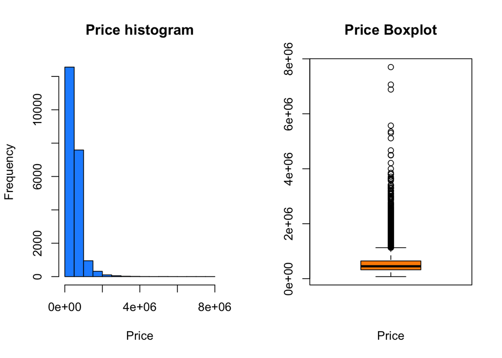

```r
#data_df = data.frame((kc_house_data))
par(mfrow = c(1,2))

#price
# from  plots, appear there are some outliers in price.
hist(kc_house_data$price, main = "Price histogram", xlab = "Price", col ="dodgerblue")
boxplot(kc_house_data$price, main = "Price Boxplot", xlab = "Price", col = "darkorange")
```

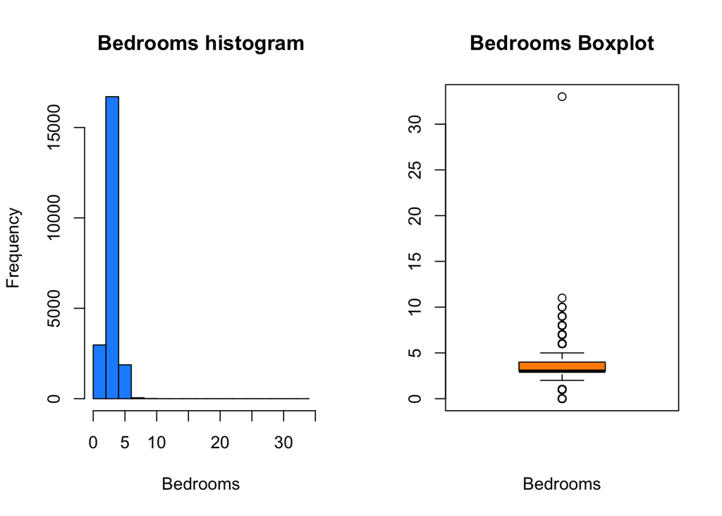

```r
#Bedrooms.
# from box plots, appear there are some outliers in bedrooms or just wrong data.
hist(kc_house_data$bedrooms, main = "Bedrooms histogram", xlab = "Bedrooms", col ="dodgerblue")
boxplot(kc_house_data$bedrooms, main = "Bedrooms Boxplot", xlab = "Bedrooms", col = "darkorange")
```

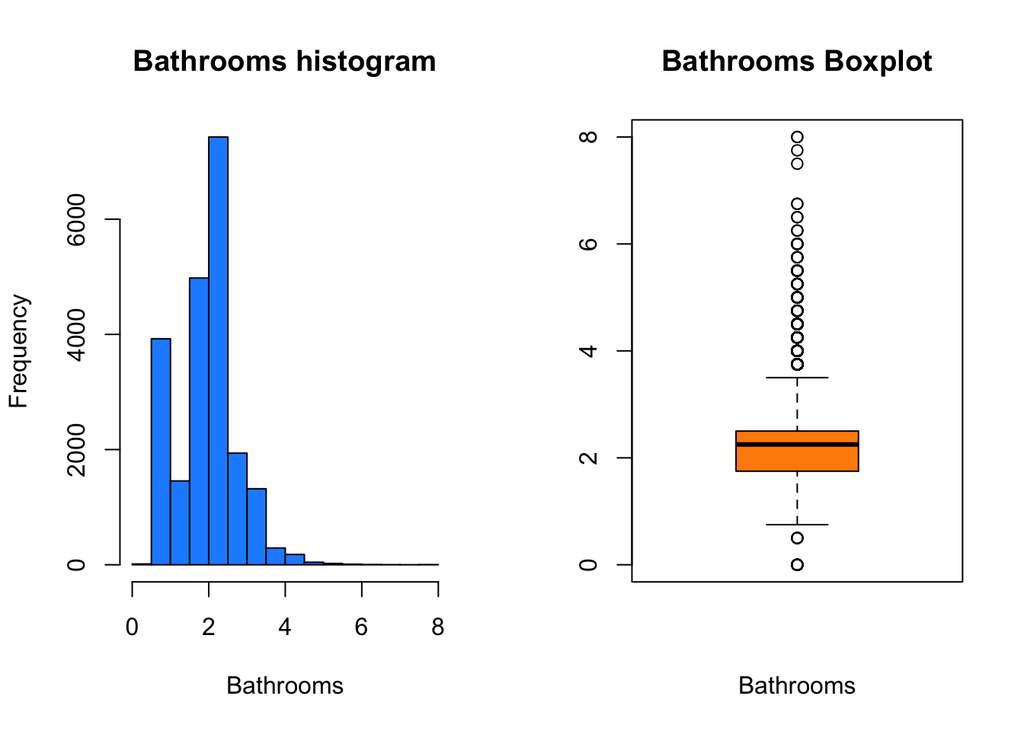

```r
#Bathrooms
hist(kc_house_data$bathrooms, main = "Bathrooms histogram", xlab = "Bathrooms", col ="dodgerblue")
boxplot(kc_house_data$bathrooms, main = "Bathrooms Boxplot", xlab = "Bathrooms", col = "darkorange")
```

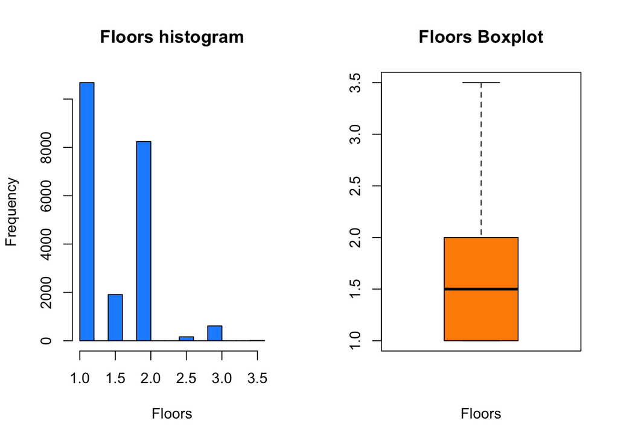

```r
#Floors
hist(kc_house_data$floors, main = "Floors histogram", xlab = "Floors", col ="dodgerblue")
boxplot(kc_house_data$floors, main = "Floors Boxplot", xlab = "Floors", col = "darkorange")
```